# Intro to R-Markdown

Zayd Omar

12/01/2022

# R Markdown Intro

We can use R-markdown to typeset our work and solutions. Since we will be doing a lot of work on R, where you will need to show your code and solutions, this might be a better option since it will directly allow you to integrate your code and responses into one neat document.

You need to know the Syntax of R-markdown, which is not too difficult to learn. You can very easily integrate some Latex functions into a markdown document (For Latex purists a better option might be to use Knitr which also allows you to integrate your code and writing together.)

# Some basics function:

1. # This is used to indicate a new section
2. ## This is used to indicate a new subsection
3. ### This is used to indicate a new subsubsection
4. Comment out text by hilighting them and clicking cmd+shft+c on MAC and cntrl+shft+c on Window
5. Italics, by putting * on both sides of the word, example *this is an italic*
6. Bold, by putting * on both sides, example **this is a bold font**
7. Bold and Italic, by putting three * on both sides, example *bold and italic*

## Latex Functions:

You can bring in a whole host of Latex functions. Primarily for us the functions related to writing equations will be the most useful.

1. An *in line* equation can be written by in the following manner $ equation $, example of an in line equation $y=mx+c$.
2. An equation on a separate line may be written as, $$ equation $$, example,
   $$y=mx+c$$
   .
3. We can also use some of the Latex fonts, such as backslash+mathbb or backslash+mathcal, example, $\mathbb{R}$, $\mathcal{L}$.

# This is a new section

## This is a new subsection

### This is a new subsubsection

Thus hashtags are used to indicate sections, if you want to use a hashtag in the document NOT signify a new section you will need to do a backslash+hastag, like this #.

# R Code Integration:

Your $\mathtt{R}$ code can be integrated into R-markdown using what is called chunks. Chunks will always have the following format,

```r
print("This chunk will only show the results and the code")
```

```
## [1] "This chunk will only show the results and the code"
```

```r
a = 1
b = 2
c = c(1,2,3,4,5,6,7,8,9)

a+b
```

```
## [1] 3
```

```r
c^2
```

```
## [1]  1  4  9 16 25 36 49 64 81
```

Here is a hidden chunk,

```
## [1] "This chunk will only show the results and not the code"
```

```
## [1] 3
```

```
## [1]  1  4  9 16 25 36 49 64 81
```

Here is another chunk, where we used some data from Tutorial 1.

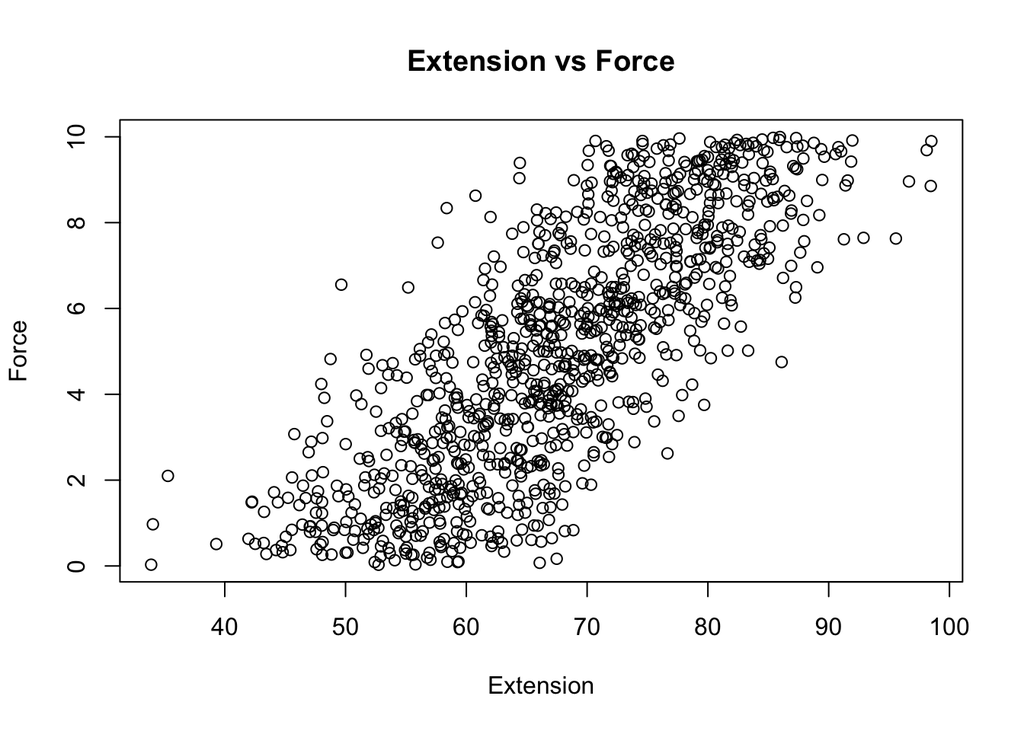

```r
data = read.csv("/Users/zaydomar/Dropbox/Zayd/Class_Notes/MATH 204 Principles of Statistics/Tutorials/Tutorial 1/Temp_Data.csv")

plot(data$Ext,data$Force, xlab = "Extension", ylab = "Force", main = "Extension vs Force" )
```